# 0401 Travel Time Variability Analysis

## Data Prep

Cells in this section cannot be run without original databases

### Read in AM peak baseline fastest option data

```r
db <- DBI::dbConnect(RSQLite::SQLite(), paste0(wd,'/20190322_0830/traveloptions.db'))
baseline_traveloptions <- tbl(db, 'traveloptions')
baseline_fastestoption <- tbl(db, sql('SELECT orig_id, dest_id, option_id, MIN(traveltime) FROM (SELECT orig_id, dest_id, option_id, traveltime FROM traveloptions WHERE legs_cycle = 0) GROUP BY orig_id, dest_id'))
baseline_fastestoption <- left_join(baseline_fastestoption, baseline_traveloptions, by = c('orig_id', 'dest_id', 'option_id')) %>% collect()
baseline_fastestoption$`MIN(traveltime)` <- NULL
# clean up
colnames(baseline_fastestoption)[c(30,31,32,42:47)] <- c('dist_nationalrail', 'legs_nationalrail', 'time_nationalrail', 'dist_riverbus', 'legs_riverbus', 'time_riverbus', 'dist_replacementbus', 'legs_replacementbus', 'time_replacementbus') # rename columns to remove dashes
dist_columns <- colnames(baseline_fastestoption)[ which(substr(colnames(baseline_fastestoption), 1, 4) == 'dist')] # convert distances to km
baseline_fastestoption[,dist_columns] <- baseline_fastestoption[,dist_columns] / 1000
rm(baseline_traveloptions, dist_columns)
DBI::dbDisconnect(db)
```

Successfully read 966287 OD pairs of data. Available columns: orig_id, dest_id, option_id, starttime, traveltime, fare, transfers, legs, dist, first_zoned_station, last_zoned_station, dist_walking, legs_walking, time_walking, dist_dlr, legs_dlr, time_dlr, dist_bus, legs_bus, time_bus, dist_cycle, legs_cycle, time_cycle, dist_tube, legs_tube, time_tube, dist_tflrail, legs_tflrail, time_tflrail, dist_nationalrail, legs_nationalrail, time_nationalrail, dist_coach, legs_coach, time_coach, dist_overground, legs_overground, time_overground, dist_tram, legs_tram, time_tram, dist_riverbus, legs_riverbus, time_riverbus, dist_replacementbus, legs_replacementbus, time_replacementbus.

### Read in observed AM peak fastest option data for 983 origins and 7 destinations

```r
## obtain directories
dirs <- list.dirs(wd, recursive = F)
dirs <- dirs[(1:length(dirs))[substr(dirs, nchar(wd) + 41, nchar(wd) + 47) == 'ampeak']]
## compile data
obs <- data.frame()
obs_i <- 1
for (dir in dirs) {
  if ('traveloptions_to_cityplus6clusters.db' %in% list.files(dir)) {
    db <- DBI::dbConnect(RSQLite::SQLite(), paste0(dir,'/traveloptions_to_cityplus6clusters.db'))
    fastestoption <- tbl(db, sql('SELECT orig_id, dest_id, MIN(traveltime) FROM (SELECT orig_id, dest_id, traveltime FROM traveloptions WHERE legs_cycle = 0) GROUP BY orig_id, dest_id')) %>% collect()
    fastestoption$obs_i <- obs_i
    obs_i <- obs_i + 1
    DBI::dbDisconnect(db)

    obs <- rbind(obs, fastestoption)
  }
}
## clean up
rm(fastestoption)
rm(db, dir, dirs, obs_i)
colnames(obs) <- c('orig_id', 'dest_id', 'traveltime', 'obs')
```

Successfully read 337168 observations of actual trip options.

```r
## calculate statistics of observed distribution of travel times and generate regressiondf
odpair_traveltime <- obs %>% group_by(orig_id,dest_id) %>% summarise(median_traveltime = quantile(traveltime, .5), traveltime_5pc = quantile(traveltime, .05), traveltime_95pc = quantile(traveltime, .95))
regressiondf <- left_join(odpair_traveltime, baseline_fastestoption, by = c('orig_id','dest_id'))
regressiondf$traveltime_95pc_minus_median <- regressiondf$traveltime_95pc - regressiondf$median_traveltime
regressiondf$traveltime_95pc_minus_5pc <- regressiondf$traveltime_95pc - regressiondf$traveltime_5pc
regressiondf$traveltime_95pc_minus_baseline <- regressiondf$traveltime_95pc - regressiondf$traveltime
```

Successfully compiled 6881 OD pairs of data on the distribution of observed travel times. Available columns: orig_id, dest_id, median_traveltime, traveltime_5pc, traveltime_95pc, option_id, starttime, traveltime, fare, transfers, legs, dist, first_zoned_station, last_zoned_station, dist_walking, legs_walking, time_walking, dist_dlr, legs_dlr, time_dlr, dist_bus, legs_bus, time_bus, dist_cycle, legs_cycle, time_cycle, dist_tube, legs_tube, time_tube, dist_tflrail, legs_tflrail, time_tflrail, dist_nationalrail, legs_nationalrail, time_nationalrail, dist_coach, legs_coach, time_coach, dist_overground, legs_overground, time_overground, dist_tram, legs_tram, time_tram, dist_riverbus, legs_riverbus, time_riverbus, dist_replacementbus, legs_replacementbus, time_replacementbus, traveltime_95pc_minus_median, traveltime_95pc_minus_5pc, traveltime_95pc_minus_baseline

### Construct travel time matrix

```r
ttm_baseline_fastestoption <- baseline_fastestoption[,c('orig_id','dest_id','traveltime')] %>% filter(dest_id %in% c('E02000001','E02000384','E02000455','E02000558','E02000649','E02000664','E02000779')) %>% spread(key = 'dest_id', value = 'traveltime')
rownames(ttm_baseline_fastestoption) <- ttm_baseline_fastestoption$orig_id
```

```
Setting row names on a tibble is deprecated.
```

```r
ttm_baseline_fastestoption$orig_id <- NULL
ttm_baseline_fastestoption[c(1:5),c(1:5)] # print first 5 x 5 square of data
```

| E02000001 | E02000384 | E02000455 | E02000558 | E02000649 |
| --- | --- | --- | --- | --- |
| 13 | 45 | 46 | 31 | 42 |
| 61 | 92 | 97 | 75 | 102 |
| 56 | 85 | 85 | 65 | 91 |
| 71 | 98 | 106 | 82 | 110 |
| 65 | 96 | 93 | 77 | 94 |

### Save out compiled data

```r
save(regressiondf, ttm_baseline_fastestoption, file = 'r_analysis_data.RData')
```

## Regression Analysis of RBTs

Cells in this section can be run with the provided .RData file

### Read in compiled data

```r
load('r_analysis_data.RData')
```

### Calculate similarity of travel times between all pairs of MSOAs based on Euclidean Distance of travel times to 7 destinations

```r
dist_baseline_fastestoption <- as.matrix(dist(ttm_baseline_fastestoption))
dim(dist_baseline_fastestoption)
```

```
[1] 983 983
```

```r
dist_baseline_fastestoption[c(1:5),c(1:5)] # print first 5 x 5 square of data
```

```
          E02000001 E02000002 E02000003 E02000004 E02000005
E02000001   0.00000 119.71215  98.55455 138.94963 119.93331
E02000002 119.71215   0.00000  27.64055  21.58703  12.52996
E02000003  98.55455  27.64055   0.00000  48.64155  31.85906
E02000004 138.94963  21.58703  48.64155   0.00000  22.78157
E02000005 119.93331  12.52996  31.85906  22.78157   0.00000
```

### Helper functions for regressions

```r
# function to prep dataframes to contain the results
prep_results_containers <- function(distance_matrix, regressiondf, ivs) {
  results_coef <- data.frame(matrix(nrow = nrow(distance_matrix), ncol = length(ivs)), row.names = rownames(distance_matrix))
  colnames(results_coef) <- ivs
  results_pval <- results_coef
  results_localrsqadj <- data.frame(local_rsq = rep(NA,nrow(ttm_baseline_fastestoption)), row.names = rownames(distance_matrix))
  results_predictions <- data.frame(matrix(nrow = nrow(regressiondf), ncol = length(ivs)), row.names = rownames(regressiondf))
  colnames(results_predictions) <- ivs
  results_containers_list <- list(results_coef, results_pval, results_localrsqadj, results_predictions)
  names(results_containers_list) <- c('results_coef', 'results_pval', 'results_localrsqadj', 'results_predictions')
  return(results_containers_list)
}
# function to carry out LWR
locally_weighted_regression <- function(regressiondf, ivs, dv, distance_matrix, results_containers_list, criticalquantile = 1) {
  rowsprocessed = 0
  print(paste('Processing local regression for', nrow(distance_matrix), 'areas.'))
  lm_formula <- as.formula(paste(dv, '~', paste(ivs, collapse = ' + ')))
  for (orig in rownames(distance_matrix)) {
    criticaldist <- quantile(distance_matrix[orig,], criticalquantile)
    localcluster <- names(distance_matrix[orig,])[which(distance_matrix[orig,] <= criticaldist)]
    regressiondf_local <- regressiondf %>% filter(orig_id %in% localcluster)
    lm_local <- lm(lm_formula, data = regressiondf_local)
    lm_local_summary <- summary(lm_local)$coefficients

    # assign local coef estimates to results
    for (dv in ivs[c(2:length(ivs))]) {
      results_containers_list$results_coef[orig,dv] <- lm_local_summary[,1][dv]
    }
    results_containers_list$results_coef[orig,'1'] <- lm_local_summary['(Intercept)',1]
    # assign local coef pvals to results
    for (dv in ivs[c(2:length(ivs))]) {
      results_containers_list$results_pval[orig,dv] <- lm_local_summary[,4][dv]
    }
    results_containers_list$results_pval[orig,'1'] <- lm_local_summary['(Intercept)',4]

    # assign local rsq to results
    results_containers_list$results_localrsqadj[orig,] <- summary(lm_local)$r.squared

    # monitor progress
    rowsprocessed <- rowsprocessed + 1
    if (rowsprocessed %% 100 == 0) {
      print(rowsprocessed)
    }

  }
  # predict DV based on local regression coefficients
  print('Predicting DV values')
  results_coef_for_join <- results_containers_list$results_coef
  results_coef_for_join$orig_id <- rownames(results_containers_list$results_coef)
  regressiondf_results <- regressiondf[,c('orig_id', 'dest_id', ivs[2:length(ivs)])] %>% left_join(results_coef_for_join, by = 'orig_id')
  results_containers_list$results_predictions[,'1'] <- regressiondf_results[,'1']

  for (dv in ivs[2:length(ivs)]) {
    results_containers_list$results_predictions[,dv] <- regressiondf_results[,paste0(dv,'.x')] * regressiondf_results[,paste0(dv,'.y')]
  }
  results_containers_list$results_predictions$prediction <- rowSums(results_containers_list$results_predictions, na.rm = T)
  print('Completed.')
  return(results_containers_list)
}
# function to plot outputs
plot_results <- function(regressiondf, results_predictions, dv, title, xlabel, ylabel) {
  pseudo_rsq <- round(1 - sum((unlist(regressiondf[,dv]) - results_predictions$prediction)^2) / sum((unlist(regressiondf[,dv]) - mean(unlist(regressiondf[,dv])))^2), 2)
  plot(unlist(regressiondf[,dv]), results_predictions$prediction, xlab = xlabel, ylab = ylabel)
  lines(c(0,200),c(0,200), col = 'red')
  title(paste(c(title, '| Spearman Corr:', round(cor(regressiondf[,dv], results_predictions$prediction, method = 'spearman'), 2), '| Pseudo Rsq:', pseudo_rsq), collapse = ' '))
}
```

## OLS Regression with Local Spillovers

### Prepare weighted mean of DV for neighbours of each area

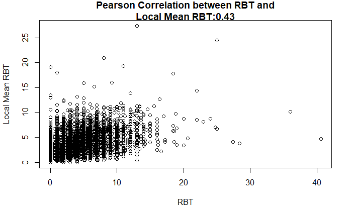

```r
dv <- 'traveltime_95pc_minus_median'
regressiondf$dv_local_mean <- 0
for (row in 1:nrow(regressiondf)) {
  orig <- regressiondf[row,]$orig_id
  dest <- regressiondf[row,]$dest_id
  criticaltime <- quantile(dist_baseline_fastestoption[orig,], .005) # 5 nearest neighbours
  localcluster <- names(dist_baseline_fastestoption[orig,])[which(dist_baseline_fastestoption[orig,] <= criticaltime)]
  localcluster <- setdiff(localcluster, orig) # exclude current pair from local cluster
  dv_local_mean <- regressiondf[,c('orig_id','dest_id',dv)] %>% filter(orig_id %in% localcluster & dest_id == dest)
  regressiondf[row,]$dv_local_mean <- mean(unlist(dv_local_mean[,dv]))
}
plot(unlist(regressiondf[,dv]), regressiondf$dv_local_mean, xlab = 'RBT', ylab = 'Local Mean RBT')
title(paste(c('Pearson Correlation between RBT and\nLocal Mean RBT:', round(cor(regressiondf[,dv], regressiondf$dv_local_mean), 2)), collapse = ''))
```

### Figure 16: Examine correlation between baseline and actual median travel times

```r
plot(regressiondf$traveltime, regressiondf$median_traveltime, xlab = 'Baseline Travel Time (min)', ylab = 'Observed Median Travel Time (min)')
lines(c(0,150),c(0,150), col = 'red')
```

[figure not shown]

```r
title(paste('Pearson Correlation: ', round(cor(regressiondf$traveltime, regressiondf$median_traveltime), 3), collapse = ''))
```

### Read in spatial data

```r
msoas <- readOGR(dsn = '../90 Data/GLA', layer = 'MSOA_2011_London_gen_MHW') # read in MSOAs shapefile
msoas <- spTransform(msoas, CRS('+init=epsg:27700')) # reproject to British National Grid
msoas <- msoas[,'MSOA11CD']
londontube <- readOGR(dsn = '../90 Data/misc', layer = 'londontube')
londontube <- spTransform(londontube, CRS('+init=epsg:27700'))
londonrail <- readOGR(dsn = '../90 Data/misc', layer = 'Tracks')
```

```r
londonrail <- spTransform(londonrail, CRS('+init=epsg:27700'))
```

### Figure 2: Visualise calculation of local mean for Stratford, E02000726

```r
# compile data for Stratford
stratford_localcluster <- data.frame(dist_baseline_fastestoption['E02000726',])
colnames(stratford_localcluster) <- 'euclidean_dist'
stratford_localcluster$'MSOA Type' <- 'Excluded from Locally Weighted Regression (LWR)'
stratford_localcluster[ which(stratford_localcluster$euclidean_dist < quantile(stratford_localcluster$euclidean_dist, .03)),]$'MSOA Type' <- 'Included in LWR'
stratford_localcluster[ which(stratford_localcluster$euclidean_dist < quantile(stratford_localcluster$euclidean_dist, .005)),]$'MSOA Type' <- 'Included in LWR and Local Mean RBT Calculation'
stratford_localcluster['E02000726','MSOA Type'] <- 'Stratford: Included in LWR'
# compile data for 7 destinations
destinations <- msoas %>% subset(MSOA11CD %in% c('E02000001','E02000384','E02000455','E02000558','E02000649','E02000664','E02000779'))
# join to spatial data
stratford_localcluster_spatial <- msoas
stratford_localcluster_spatial@data <- left_join(stratford_localcluster_spatial@data, tibble::rownames_to_column(stratford_localcluster), by = c('MSOA11CD' = 'rowname'))
```

```
Column `MSOA11CD`/`rowname` joining factor and character vector, coercing into character vector
```

```r
# plot map
tmap_mode('plot') # set to plotting mode
```

```
tmap mode set to plotting
```

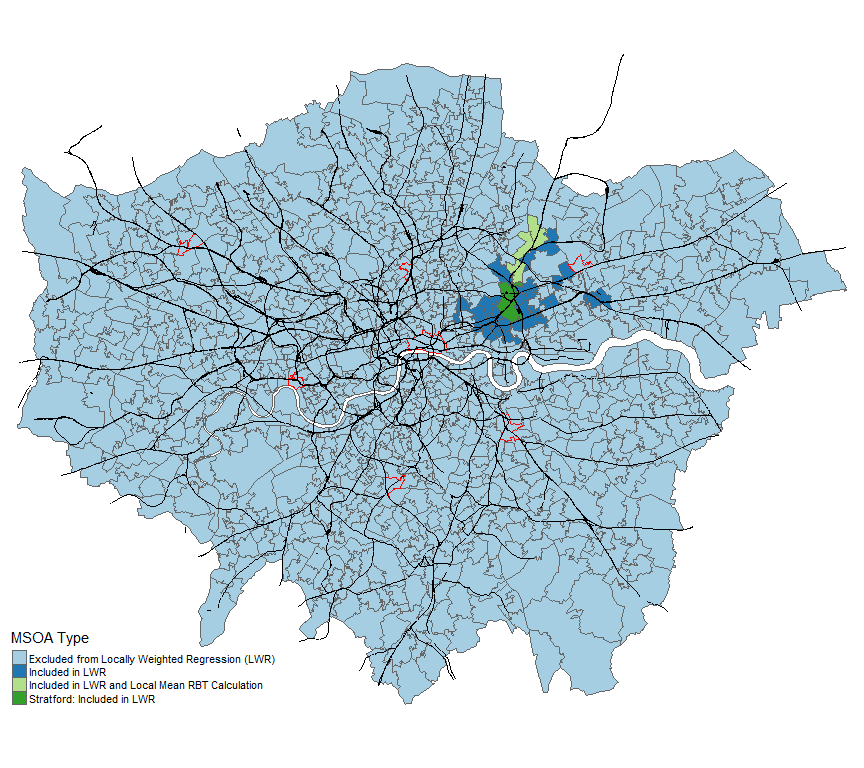

```r
tm_shape(stratford_localcluster_spatial) +
  tm_polygons('MSOA Type', palette = 'Paired') +
tm_shape(destinations) +
  tm_borders(col = 'red') +
tm_shape(londontube) +
  tm_lines(lwd = .1, col = 'black') +
tm_shape(londonrail) +
  tm_lines(lwd = .1, col = 'black') +
tm_layout(legend.position = c('left','bottom'), outer.margins = c(0,0,0,0), frame = F)
```

### Declare regression variables

```r
ivs <- c('1','dv_local_mean','transfers','dist_bus','dist_coach','dist_dlr','dist_nationalrail','dist_overground','dist_riverbus','dist_tflrail','dist_tram','dist_tube','dist_walking')
lm_formula <- as.formula(paste(dv, '~', paste(ivs, collapse = ' + ')))
```

### Execute OLS Regression with Local Spillovers

```r
lm_global_local_spillovers <- lm(lm_formula, data = regressiondf)
summary(lm_global_local_spillovers)
```

```
Call:
lm(formula = lm_formula, data = regressiondf)

Residuals:
    Min      1Q  Median      3Q     Max
-12.979  -1.616  -0.453   1.173  35.597

Coefficients:
                    Estimate Std. Error t value Pr(>|t|)
(Intercept)        1.330e+00  1.312e-01  10.140  < 2e-16 ***
dv_local_mean      5.214e-01  1.759e-02  29.640  < 2e-16 ***
transfers          2.851e-01  4.134e-02   6.897 5.79e-12 ***
dist_bus           2.526e-01  1.922e-02  13.142  < 2e-16 ***
dist_coach        -5.411e-01  8.262e-01  -0.655 0.512564
dist_dlr          -6.999e-02  1.831e-02  -3.823 0.000133 ***
dist_nationalrail  2.514e-02  5.712e-03   4.402 1.09e-05 ***
dist_overground   -1.272e-05  1.562e-02  -0.001 0.999350
dist_riverbus      2.758e-01  3.745e-01   0.736 0.461490
dist_tflrail       1.233e-02  1.057e-02   1.167 0.243304
dist_tram         -2.166e-01  5.156e-02  -4.201 2.69e-05 ***
dist_tube         -2.367e-02  4.811e-03  -4.919 8.89e-07 ***
dist_walking      -1.134e-01  8.207e-02  -1.382 0.167003
---
Signif. codes:  0 *** 0.001 ** 0.01 * 0.05 . 0.1   1

Residual standard error: 2.768 on 6868 degrees of freedom
Multiple R-squared:  0.2349,    Adjusted R-squared:  0.2336
F-statistic: 175.8 on 12 and 6868 DF,  p-value: < 2.2e-16
```

## Locally Weighted Regression with Local Spillovers

### Set up dataframes to store results

```r
results_lwr02 <- prep_results_containers(dist_baseline_fastestoption, regressiondf, ivs)
```

### Carry out locally weighted regression

```r
results_lwr02 <- locally_weighted_regression(regressiondf, ivs, dv, dist_baseline_fastestoption, results_lwr02, .03)
```

```
[1] "Processing local regression for 983 areas."
[1] 100
[1] 200
[1] 300
[1] 400
[1] 500
[1] 600
[1] 700
[1] 800
[1] 900
[1] "Predicting DV values"
[1] "Completed."
```

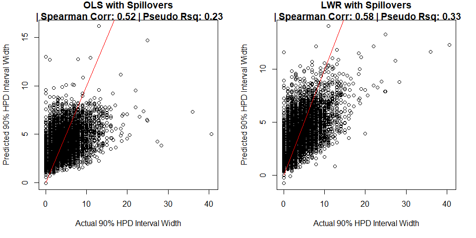

```r
par(mfrow = c(1,2))
plot_results(regressiondf, data.frame(prediction = lm_global_local_spillovers$fitted.values), dv, 'OLS with Spillovers\n', xlabel = 'Actual 90% HPD Interval Width', ylabel = 'Predicted 90% HPD Interval Width')
plot_results(regressiondf, results_lwr02$results_predictions, dv, 'LWR with Spillovers\n', xlabel = 'Actual 90% HPD Interval Width', ylabel = 'Predicted 90% HPD Interval Width')
```

```r
summary(results_lwr02$results_localrsqadj$local_rsq)
```

```
   Min. 1st Qu.  Median    Mean 3rd Qu.    Max.
0.04852 0.16565 0.23425 0.27811 0.37895 0.68915
```

## Visualisation of Coefficients

### join results

```r
results_lwr02_coefs_spatial <- msoas # creating a copy to work with
results_lwr02_coefs_spatial@data <- left_join(results_lwr02_coefs_spatial@data, tibble::rownames_to_column(results_lwr02$results_coef), by = c('MSOA11CD' = 'rowname')) # joining results to spatial
```

```
Column `MSOA11CD`/`rowname` joining factor and character vector, coercing into character vector
```

```r
rownames(results_lwr02_coefs_spatial@data) <- results_lwr02_coefs_spatial@data$MSOA11CD # shift MSOA IDs to rownames
results_lwr02_coefs_spatial@data$MSOA11CD <- NULL
colnames(results_lwr02_coefs_spatial@data) <- c('Intercept', 'Local Mean RBT', 'Transfers', 'Bus km', 'Coach km', 'DLR km', 'National Rail km', 'Overground km', 'Riverbus km', 'TfL Rail km', 'Tram km', 'Underground km', 'Walking km')
results_lwr02_pvals_spatial <- msoas # creating a copy to work with
results_lwr02_pvals_spatial@data <- left_join(results_lwr02_pvals_spatial@data, tibble::rownames_to_column(results_lwr02$results_pval), by = c('MSOA11CD' = 'rowname')) # joining results to spatial
```

```
Column `MSOA11CD`/`rowname` joining factor and character vector, coercing into character vector
```

```r
rownames(results_lwr02_pvals_spatial@data) <- results_lwr02_pvals_spatial@data$MSOA11CD # shift MSOA IDs to rownames
results_lwr02_pvals_spatial@data$MSOA11CD <- NULL
colnames(results_lwr02_pvals_spatial@data) <- c('Intercept', 'Local Mean RBT', 'Transfers', 'Bus km', 'Coach km', 'DLR km', 'National Rail km', 'Overground km', 'Riverbus km', 'TfL Rail km', 'Tram km', 'Underground km', 'Walking km')
results_lwr02_localrsqadj_spatial <- msoas # creating a copy to work with
results_lwr02_localrsqadj_spatial@data <- left_join(results_lwr02_localrsqadj_spatial@data, tibble::rownames_to_column(results_lwr02$results_localrsqadj), by = c('MSOA11CD' = 'rowname')) # joining results to spatial
```

```
Column `MSOA11CD`/`rowname` joining factor and character vector, coercing into character vector
```

```r
rownames(results_lwr02_localrsqadj_spatial@data) <- results_lwr02_localrsqadj_spatial@data$MSOA11CD # shift MSOA IDs to rownames
results_lwr02_localrsqadj_spatial@data$MSOA11CD <- NULL
colnames(results_lwr02_localrsqadj_spatial@data) <- c('Local Rsq Adj')
# masking away coef estimates if pval < .1
# using https://stackoverflow.com/questions/39412241/uncover-values-of-one-data-frame-with-another-mask-data-frame
is.na(results_lwr02_coefs_spatial@data) <- !as.matrix(results_lwr02_pvals_spatial@data < .1)
```

### Figure 13: Visualise local coefficient estimates

```r
tmap_mode('plot') # set to plotting mode
```

```
tmap mode set to plotting
```

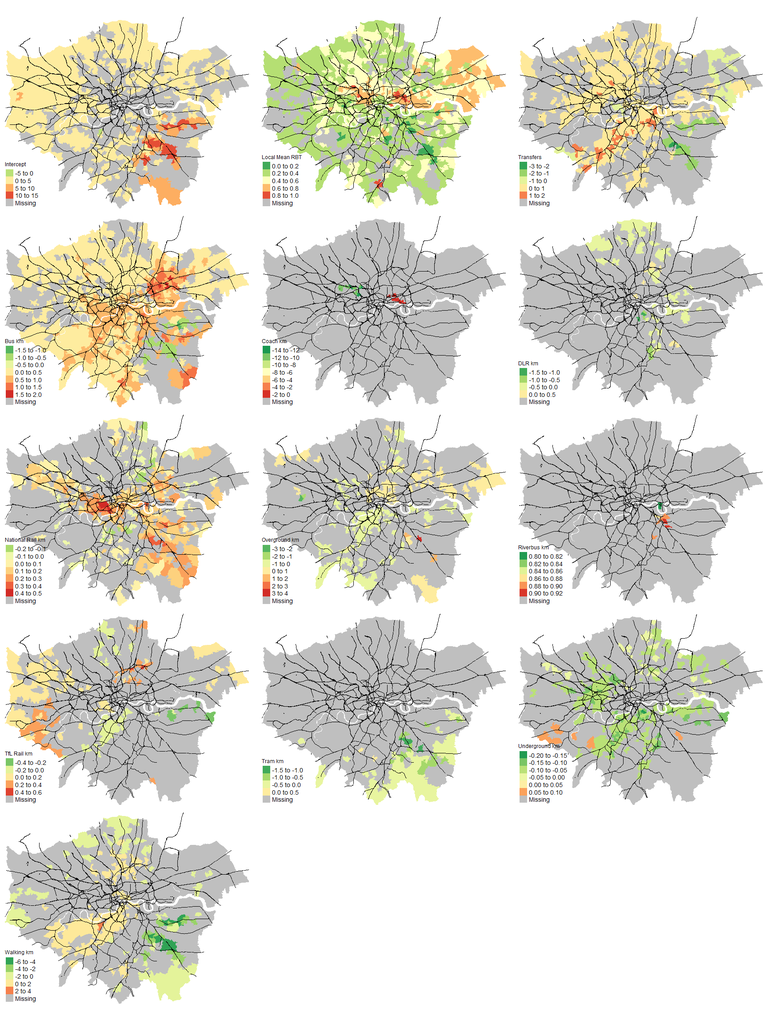

```r
tm_shape(results_lwr02_coefs_spatial) +
  tm_fill(c(colnames(results_lwr02_coefs_spatial@data)), palette = '-RdYlGn') +
tm_shape(londontube) +
  tm_lines(lwd = .1, col = 'black') +
tm_shape(londonrail) +
  tm_lines(lwd = .1, col = 'black') +
tm_facets(ncol = 3, nrow = ceiling(ncol(results_lwr02_coefs_spatial) / 3), sync = T) +
tm_layout(legend.position = c('left','bottom'), outer.margins = c(0,0,0,0), frame = F, legend.text.size = 1.5, legend.title.size = 1.5)
```

```r
tmap_mode('plot') # set to plotting mode
```

```
tmap mode set to plotting
```

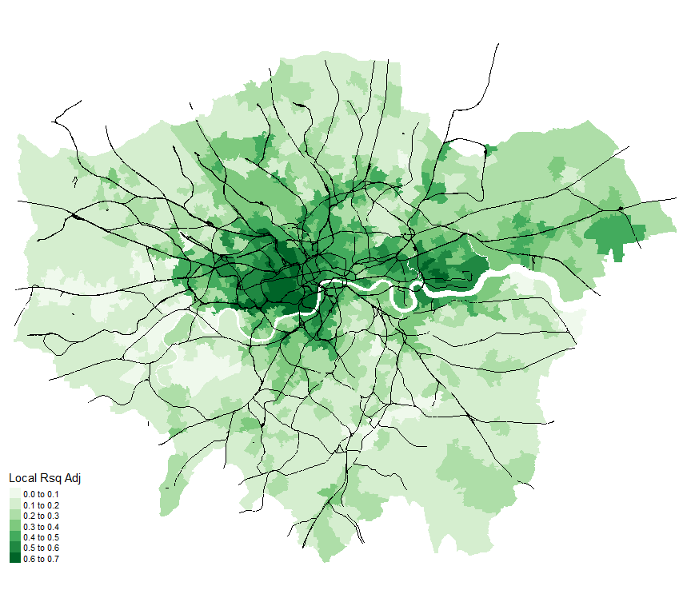

```r
tm_shape(results_lwr02_localrsqadj_spatial) +
  tm_fill('Local Rsq Adj', palette = 'Greens') +
tm_shape(londontube) +
  tm_lines(lwd = .1, col = 'black') +
tm_shape(londonrail) +
  tm_lines(lwd = .1, col = 'black') +
tm_layout(outer.margins = c(0,0,0,0), legend.position = c('left','bottom'), frame = F)
```

### Figure 20: visualise p-values for local coefficient estimates

```r
tmap_mode('plot') # set to plotting mode
```

```
tmap mode set to plotting
```

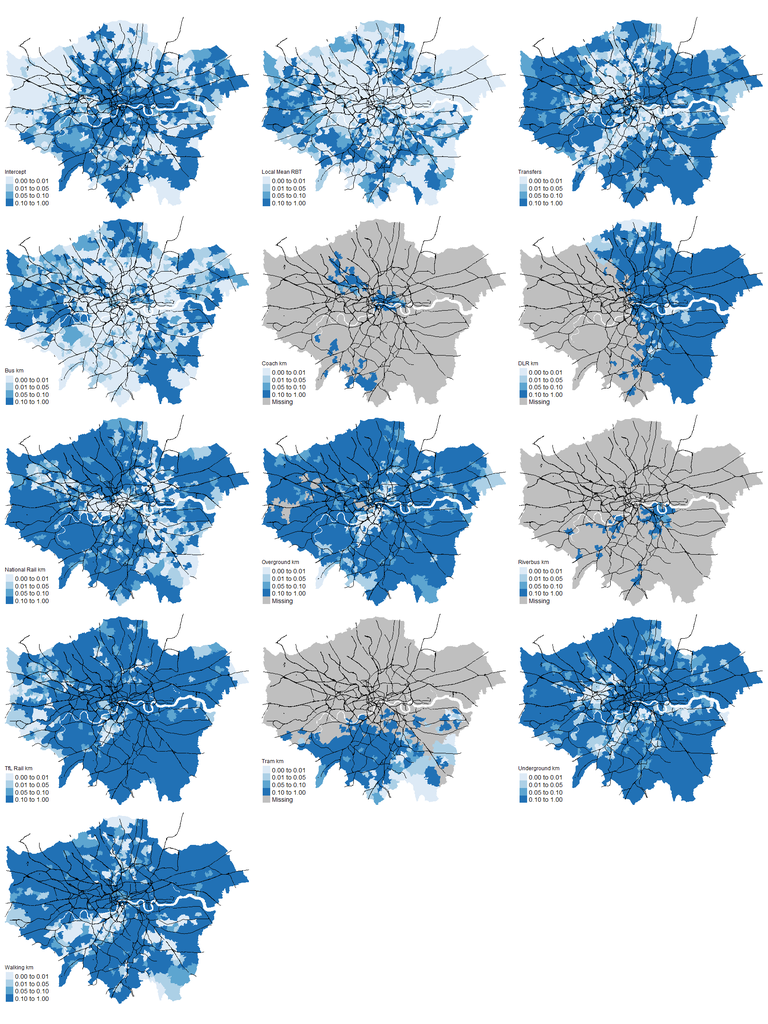

```r
tm_shape(results_lwr02_pvals_spatial) +
  tm_fill(c(colnames(results_lwr02_pvals_spatial@data)), palette = 'Blues', style = 'fixed', breaks = c(0,.01,.05,.1,1)) +
tm_shape(londontube) +
  tm_lines(lwd = .1, col = 'black') +
tm_shape(londonrail) +
  tm_lines(lwd = .1, col = 'black') +
tm_facets(ncol = 3, nrow = ceiling(ncol(results_lwr02_pvals_spatial) / 3), sync = T) +
tm_layout(legend.position = c('left','bottom'), outer.margins = c(0,0,0,0), legend.text.size = 1.5, legend.title.size = 1.5, frame = F)
```

## Compile regression results table

```r
regressiontable <- matrix(nrow = length(ivs), ncol = 8, dimnames = list(c(ivs),c('OLS with Spillovers','OLS with Spillovers 95CI_L','OLS with Spillovers 95CI_U','LWR Min','LWR 25%','LWR 50%','LWR 75%','LWR Max')))
for (row in rownames(regressiontable)) {
  lwr_quantiles <- round(summary(results_lwr02$results_coef[,row]),3)
  regressiontable[row,'LWR Min'] <- lwr_quantiles[1]
  regressiontable[row,'LWR 25%'] <- lwr_quantiles[2]
  regressiontable[row,'LWR 50%'] <- lwr_quantiles[3]
  regressiontable[row,'LWR 75%'] <- lwr_quantiles[5]
  regressiontable[row,'LWR Max'] <- lwr_quantiles[6]
}
rownames(regressiontable)[1] <- '(Intercept)'
for (row in rownames(regressiontable)) {
  regressiontable[row,'OLS with Spillovers'] <- round(lm_global_local_spillovers$coefficients[row],3)
  regressiontable[row,'OLS with Spillovers 95CI_L'] <- round(confint(lm_global_local_spillovers)[row,1],3)
  regressiontable[row,'OLS with Spillovers 95CI_U'] <- round(confint(lm_global_local_spillovers)[row,2],3)
}
```

## Write out useful data

```r
write.csv(results_lwr02$results_coef, 'results_lwr02_coefs.csv')
write.csv(regressiontable, 'regressiontable.csv')
```